# Part 4

## Building a digit classifier on the SVHN (Street View Housing Number) dataset.

```python
import numpy as np
import pandas as pd
import os
import csv
import matplotlib.pyplot as plt
%matplotlib inline
import seaborn as sns
from termcolor import colored
import warnings
warnings.filterwarnings('ignore')

from tensorflow import keras
from tensorflow.keras import layers
from tensorflow.keras import optimizers,regularizers
from tensorflow.keras.layers import Flatten, Dense
from tensorflow.keras.layers import Reshape, Activation
from tensorflow.keras.activations import softmax
from tensorflow.keras.utils import to_categorical

from tensorflow.python.keras.models import Sequential
from tensorflow.python.keras.wrappers.scikit_learn import KerasRegressor

from keras.layers import Dropout,BatchNormalization, Activation

from keras.callbacks import ModelCheckpoint, EarlyStopping

import tensorflow as tf
print(tf.__version__)
```

```
2.4.1
```

```python
import random
random.seed(0)
```

```python
from google.colab import drive
drive.mount('/content/drive')
```

```python
path = '/content/drive/MyDrive/Part - 4 - Autonomous_Vehicles_SVHN_single_grey1.h5'
```

```python
import h5py
print(colored('\x1B[1m Loading dataset.....','blue'))
df = h5py.File(path, 'r')
```

```
 Loading dataset.....
```

```python
print(colored('\x1B[1m Defining dataset.....','blue'))
df.keys()
```

```
 Defining dataset.....
```

```
<KeysViewHDF5 ['X_test', 'X_train', 'X_val', 'y_test', 'y_train', 'y_val']>
```

```python
print(colored('\x1B[1m Initializing Train, Cross_val and Test sets from dataset.....','blue'))

X_train = df['X_train'][:]
y_train = df['y_train'][:]

X_val = df['X_val'][:]
y_val = df['y_val'][:]

X_test = df['X_test'][:]
y_test = df['y_test'][:]
```

```
 Initializing Train, Cross_val and Test sets from dataset.....
```

```python
print(colored('\x1B[1m Checking shape of Train, Cross_val and Test sets....','blue'))
print('Train X:',X_train.shape,' y: ', y_train.shape)
print('\nCross_val X: ',X_val.shape,' y: ',y_val.shape)
print('\nTest X: ',X_test.shape,' y: ',y_test.shape)
```

```
 Checking shape of Train, Cross_val and Test sets....
Train X: (42000, 32, 32)  y:  (42000,)

Cross_val X:  (60000, 32, 32)  y:  (60000,)

Test X:  (18000, 32, 32)  y:  (18000,)
```

```python
print(colored('\x1B[1m Initializing Rows and Columns of sets....','blue'))
img_rows=X_train.shape[1]
img_cols=X_train.shape[2]
```

```
 Initializing Rows and Columns of sets....
```

## Visualizations

```
 Visualization....
```

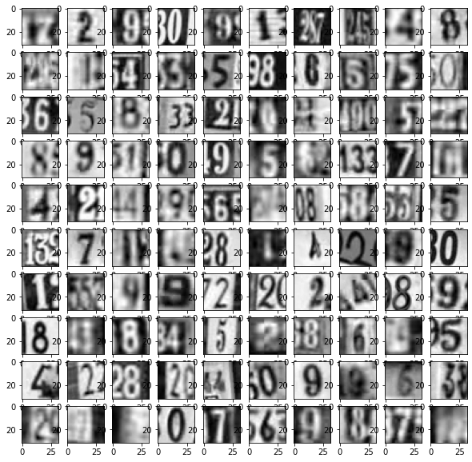

```python
print(colored('\x1B[1m Visualization....','blue'))
fig = plt.figure(figsize = (10,10))

rows = 10
columns = 10
w = 10
h = 10

for i in range(1, rows * columns + 1):
    img = X_test[i]
    fig.add_subplot(rows, columns,i)
    plt.imshow(img, cmap = 'gray')
plt.show()
```

```
 Let's see some other images also and their labels'....
Label for image at index 1 is 0
Label for image at index 2 is 0
Label for image at index 3 is 0
Label for image at index 4 is 0
Label for image at index 5 is 0
Label for image at index 6 is 0
Label for image at index 7 is 0
Label for image at index 8 is 0
Label for image at index 9 is 0
Label for image at index 10 is 0
```

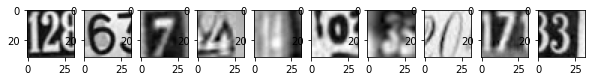

```python
print(colored('''\x1B[1m Let's see some other images also and their labels'....''','blue'))

plt.figure(figsize=(10,1))
for i in range(10):
    plt.subplot(1,10,i+1)
    plt.imshow(X_train[i].reshape(32,32),cmap='gray')
    print(f'Label for image at index {i+1} is {np.argmax(y_train[0:10][i])}')
```

```
label for each of the below image: 0
label for each of the below image: 0
label for each of the below image: 0
label for each of the below image: 0
label for each of the below image: 0
label for each of the below image: 0
label for each of the below image: 0
label for each of the below image: 0
label for each of the below image: 0
label for each of the below image: 0
```

```python
# visualizing the first 10 images in the dataset and their labels
%matplotlib inline
import matplotlib.pyplot as plt
plt.figure(figsize=(10, 1))
for i in range(10):
    plt.subplot(1, 10, i+1)
    plt.imshow(X_train[i].reshape(32, 32), cmap="gray")
    plt.axis('off')
    print('label for each of the below image: %s' % (np.argmax(y_train[0:10][i])))
plt.show()
```

[output not shown]

### Building Fully Connected Network model to classify these images.

#### FC needs data to be in the format of No. of Examples, Height * Width

```python
print(colored('\x1B[1m Reshaping the data according to model....','blue'))
X_train = X_train.reshape(X_train.shape[0], img_rows * img_cols) #32*32
X_test = X_test.reshape(X_test.shape[0], img_rows * img_cols)
X_val = X_val.reshape(X_val.shape[0], img_rows * img_cols)
```

```
 Reshaping the data according to model....
```

```python
print(colored('\x1B[1m Checking shape after reshape of Train, Cross_val and Test sets....','blue'))
print(f'X_train set contains {X_train.shape}')
print(f'y_rain set contains {y_train.shape}')
print(f'X_val set contains {X_val.shape}')
print(f'y_val set contains {y_val.shape}')
print(f'X_test set contains {X_test.shape}')
print(f'y_test set contains {y_test.shape}')
```

```
 Checking shape after reshape of Train, Cross_val and Test sets....
X_train set contains (42000, 1024)
y_rain set contains (42000,)
X_val set contains (60000, 1024)
y_val set contains (60000,)
X_test set contains (18000, 1024)
y_test set contains (18000,)
```

```python
print(colored('\x1B[1m Checking format type of reshaped sets.....','blue'))
X_train[0]
```

```
 Checking format type of reshaped sets.....
```

```
array([33.0704, 30.2601, 26.852 , ..., 49.6682, 50.853 , 53.0377],
      dtype=float32)
```

### Normalizing the input to ensures none of the columns would dominate the other

```python
print(colored('\x1B[1m Normalizing sets....','blue'))
X_train = X_train/ 255
X_val = X_val/ 255
X_test = X_test/255
```

```
 Normalizing sets....
```

```python
print(colored('\x1B[1m Checking format type of y_train sets.....','blue'))
y_train
```

```
 Checking format type of y_train sets.....
```

```
array([2, 6, 7, ..., 7, 0, 4], dtype=uint8)
```

### The target needs to be converted into One Hot Encoding vectors, so it would lead to dominating of one column on the others.

```python
print(colored('\x1B[1m One hot encoding the traget class variable....','blue'))
print(f'\nBefore converting to one hot encoding {y_train[0]}')
y_train = to_categorical(y_train, num_classes=10)
y_val = to_categorical(y_val, num_classes=10)
y_test = to_categorical(y_test, num_classes=10)
```

```
 One hot encoding the traget class variable....

Before converting to one hot encoding 2
```

```python
print(f'After converting to one hot encoding {y_train[0]}')
```

```
After converting to one hot encoding [0. 0. 1. 0. 0. 0. 0. 0. 0. 0.]
```

### Building Fully Connected Network model

```python
print(colored('\x1B[1m Building model....','blue'))
model = Sequential()
model.add(Dense(100, input_shape = (1024, ), activation = 'relu')) #hidden layer
model.add(Dense(10, activation = 'softmax'))
```

```
 Building model....
```

```python
print(colored('\x1B[1m Model Summary....','blue'))
model.summary()
```

```
 Model Summary....
Model: "sequential"
_________________________________________________________________
Layer (type)                 Output Shape              Param #
=================================================================
dense (Dense)                (None, 100)               102500
_________________________________________________________________
dense_1 (Dense)              (None, 10)                1010
=================================================================
Total params: 103,510
Trainable params: 103,510
Non-trainable params: 0
_________________________________________________________________
```

```python
print(colored('\x1B[1m Compiling model....','blue'))
model.compile(loss='categorical_crossentropy', metrics=['accuracy'], optimizer='adam')
```

```
 Compiling model....
```

```python
print(colored('\x1B[1m Fitting and training the model....','blue'))
model.fit(X_train,y_train, validation_data=(X_val,y_val),epochs=50, batch_size=64, verbose=1)
```

```
 Fitting and training the model....
```

```
<tensorflow.python.keras.callbacks.History at 0x7f21cba63290>
```

```python
print(colored('\x1B[1m Testing the model on train set....','blue'))
loss,accu=model.evaluate(X_train,y_train)
print('Loss on train set:',loss)
print('Accuracy of train set:',accu)
```

```
 Testing the model on train set....
Loss on train set: 1.969312071800232
Accuracy of train set: 0.2701190412044525
```

```python
print(colored('\x1B[1m Testing the model on test set....','blue'))
loss,accu=model.evaluate(X_test,y_test)
print('Loss on test set:',loss)
print('Accuracy of test set:',accu)
```

```
 Testing the model on test set....
Loss on test set: 1.987395167350769
Accuracy of test set: 0.27077779173851013
```

#### Loss on train set: 1.96

#### Loss on test set: 1.98

#### Accuracy of train set: 0.27

#### Accuracy of test set: 0.27

#### Model is very poor as both accuracies are very less and both losses are very high

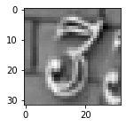

```
2
```

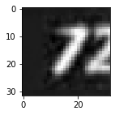

```
7
```

```python
plt.figure(figsize = (2,2))
plt.imshow(X_test[5000].reshape(32,32), cmap = 'gray') #image, reshape size, cmap
plt.show()
print(np.argmax(model.predict(X_test[5000].reshape(1,1024))))

plt.figure(figsize = (2,2))
plt.imshow(X_test[9876].reshape(32,32), cmap = 'gray') #image, reshape size, cmap
plt.show()
print(np.argmax(model.predict(X_test[9876].reshape(1,1024))))
```

```python
print(f'Value of X_test[100] label {y_test[101]}')
```

```
Value of X_test[100] label [0. 0. 0. 0. 0. 0. 0. 1. 0. 0.]
```

# Building different models in different ways

### Model-1 (Basic model with default values and vanilla SGD optimizer)

```python
def model_1(iterations):
    hidden_nodes=256
    output_nodes=10
    iterations=iterations

    model = Sequential()
    model.add(Reshape((1024,), input_shape=(32,32,), name='Input_layer'))
    model.add(BatchNormalization())
    model.add(Dense(hidden_nodes,activation='relu'))
    model.add(Dense(hidden_nodes,activation='relu'))

    model.add(Dense(output_nodes, activation='softmax'))

    #Compile the model
    model.compile(loss='categorical_crossentropy', optimizer='sgd', metrics=['accuracy'])

    #Fit the model
    model.fit(X_train,y_train,epochs=iterations, batch_size=1000, verbose=1)

    scores=[]
    score = model.evaluate(X_train,y_train, verbose=2)
    print(colored('\n\x1B[1mTrain loss:','red'),score[0])
    print(colored('\x1B[1mTrain Accuracy:','green'),score[1],'\n')
    scores.append(score)
    score = model.evaluate(X_val,y_val, verbose=2)
    print(colored('\n\x1B[1mValidation loss:','red'),score[0])
    print(colored('\x1B[1mValidation Accuracy:','green'),score[1],'\n')
    scores.append(score)
    score = model.evaluate(X_test,y_test, verbose=2)
    print(colored('\n\x1B[1mTest loss:','red'),score[0])
    print(colored('\x1B[1mTest Accuracy:','green'),score[1],'\n')
    scores.append(score)
    return scores
```

```python
print(colored('\x1B[1m Training the model with 1 no. of eopch....','blue'))
```

```
 Training the model with 1 no. of eopch....
```

```python
model_1(1)
```

```
WARNING:tensorflow:Model was constructed with shape (None, 32, 32) for input KerasTensor(type_spec=TensorSpec(shape=(None, 32, 32), dtype=tf.float32, name='Input_layer_input'), name='Input_layer_input', description="created by layer 'Input_layer_input'"), but it was called on an input with incompati…
WARNING:tensorflow:Model was constructed with shape (None, 32, 32) for input KerasTensor(type_spec=TensorSpec(shape=(None, 32, 32), dtype=tf.float32, name='Input_layer_input'), name='Input_layer_input', description="created by layer 'Input_layer_input'"), but it was called on an input with incompati…
WARNING:tensorflow:Model was constructed with shape (None, 32, 32) for input KerasTensor(type_spec=TensorSpec(shape=(None, 32, 32), dtype=tf.float32, name='Input_layer_input'), name='Input_layer_input', description="created by layer 'Input_layer_input'"), but it was called on an input with incompati…
1313/1313 - 2s - loss: 2.2951 - accuracy: 0.1229

Train loss: 2.2950527667999268
Train Accuracy: 0.12290476262569427

WARNING:tensorflow:Model was constructed with shape (None, 32, 32) for input KerasTensor(type_spec=TensorSpec(shape=(None, 32, 32), dtype=tf.float32, name='Input_layer_input'), name='Input_layer_input', description="created by layer 'Input_layer_input'"), but it was called on an input with incompati…
1875/1875 - 4s - loss: 2.2952 - accuracy: 0.1240

Validation loss: 2.2952048778533936
Validation Accuracy: 0.1240166649222374

563/563 - 1s - loss: 2.2956 - accuracy: 0.1266

Test loss: 2.2955639362335205
Test Accuracy: 0.1266111135482788
```

```
[[2.2950527667999268, 0.12290476262569427],
 [2.2952048778533936, 0.1240166649222374],
 [2.2955639362335205, 0.1266111135482788]]
```

#### Train loss: 2.295

#### Validation loss: 2.295

#### Test loss: 2.295

#### Train Accuracy: 0.122

#### Validation Accuracy: 0.124

#### Test Accuracy: 0.126

#### Model-1 is very poor as all the accuracies are very less and all the losses are very high

```python
print(colored('\x1B[1m Training the model with 100 no. of eopch....','blue'))
```

```
 Training the model with 100 no. of eopch....
```

```python
scores = model_1(100)
```

```
WARNING:tensorflow:Model was constructed with shape (None, 32, 32) for input KerasTensor(type_spec=TensorSpec(shape=(None, 32, 32), dtype=tf.float32, name='Input_layer_input'), name='Input_layer_input', description="created by layer 'Input_layer_input'"), but it was called on an input with incompati…
WARNING:tensorflow:Model was constructed with shape (None, 32, 32) for input KerasTensor(type_spec=TensorSpec(shape=(None, 32, 32), dtype=tf.float32, name='Input_layer_input'), name='Input_layer_input', description="created by layer 'Input_layer_input'"), but it was called on an input with incompati…
WARNING:tensorflow:Model was constructed with shape (None, 32, 32) for input KerasTensor(type_spec=TensorSpec(shape=(None, 32, 32), dtype=tf.float32, name='Input_layer_input'), name='Input_layer_input', description="created by layer 'Input_layer_input'"), but it was called on an input with incompati…
1313/1313 - 2s - loss: 0.5960 - accuracy: 0.8295

Train loss: 0.5959588289260864
Train Accuracy: 0.8295238018035889

WARNING:tensorflow:Model was constructed with shape (None, 32, 32) for input KerasTensor(type_spec=TensorSpec(shape=(None, 32, 32), dtype=tf.float32, name='Input_layer_input'), name='Input_layer_input', description="created by layer 'Input_layer_input'"), but it was called on an input with incompati…
1875/1875 - 4s - loss: 0.6287 - accuracy: 0.8207

Validation loss: 0.6286967992782593
Validation Accuracy: 0.8207166790962219

563/563 - 1s - loss: 0.7051 - accuracy: 0.8002

Test loss: 0.7050851583480835
Test Accuracy: 0.800166666507721
```

```python
print(colored('\x1B[1mTraining Dataset Loss is: ','red'),(scores[0][0]))
print(colored('\x1B[1mTraining Dataset Accuracy is: ','green'),(scores[0][1]))
print(colored('\n\x1B[1mValidation Dataset Loss is: ','red'),(scores[1][0]))
print(colored('\x1B[1mValidation Dataset Accuracy is: ','green'),(scores[1][1]))
print(colored('\n\x1B[1mTest Dataset Loss is: ','red'),(scores[2][0]))
print(colored('\x1B[1mTest Dataset Accuracy is: ','green'),(scores[2][1]))
```

```
Training Dataset Loss is:  0.5959588289260864
Training Dataset Accuracy is:  0.8295238018035889

Validation Dataset Loss is:  0.6286967992782593
Validation Dataset Accuracy is:  0.8207166790962219

Test Dataset Loss is:  0.7050851583480835
Test Dataset Accuracy is:  0.800166666507721
```

#### Train loss: 0.595

#### Validation loss: 0.628

#### Test loss: 0.705

#### Train Accuracy: 0.829

#### Validation Accuracy: 0.820

#### Test Accuracy: 0.8001

#### Model-1 with 100 epochs is moderate as the accuracies are good but the losses are still high

### Model-2 (with More Layers, Dropout Layer, Custom Adam Optimizer and Hyperparameters)

```python
def model_2(iterations, lr, Lambda, verb=0, eval_test=False):
    learning_rate=lr
    hidden_nodes=256
    output_nodes=10
    iterations=iterations
    # For early stopping of model.
    callbacks=tf.keras.callbacks.EarlyStopping(monitor='loss', patience=3)
    #model
    model = Sequential()
    model.add(Reshape((1024,), input_shape=(32,32,), name='Input_layer'))
    model.add(BatchNormalization())
    model.add(Dense(hidden_nodes,activation='relu'))
    model.add(Dense(hidden_nodes,activation='relu'))

    model.add(Dropout(0.3))

    model.add(Dense(hidden_nodes,activation='relu'))
    model.add(Dense(hidden_nodes,activation='relu'))

    model.add(Dense(output_nodes, activation='softmax', kernel_regularizer=regularizers.l2(Lambda)))
    # adam optmizer with custom learning rate
    adam= optimizers.Adam(lr=learning_rate)
    #Compile the model
    model.compile(loss='categorical_crossentropy', optimizer=adam, metrics=['accuracy'])

    #Fit the model
    model.fit(X_train,y_train, validation_data=(X_val,y_val),epochs=iterations, batch_size=1000, verbose=verb, callbacks=[callbacks])

    if eval_test == True:
        scores=[]
        score = model.evaluate(X_train,y_train, verbose=0)
        print(colored('\n\x1B[1mTrain loss:','red'),score[0])
        print(colored('\x1B[1mTrain Accuracy:','green'),score[1],'\n')
        scores.append(score)
        score = model.evaluate(X_val,y_val, verbose=0)
        print(colored('\n\x1B[1mValidation loss:','red'),score[0])
        print(colored('\x1B[1mValidation Accuracy:','green'),score[1],'\n')
        scores.append(score)
        score = model.evaluate(X_test,y_test, verbose=0)
        print(colored('\n\x1B[1mTest loss:','red'),score[0])
        print(colored('\x1B[1mTest Accuracy:','green'),score[1],'\n')
        scores.append(score)
        return scores
    else:
        score = model.evaluate(X_val,y_val, verbose=(verb+1)%2)
        print(colored('\n\x1B[1mValidation loss:','red'),score[0])
        print(colored('\x1B[1mValidation Accuracy:','green'),score[1],'\n')
        return score
```

```python
print(colored('\x1B[1mTraining the model with\nNo. of eopch = 1\nLearning Rate = .0001\nLambda = 0','blue'))
```

```
Training the model with
No. of eopch = 1
Learning Rate = .0001
Lambda = 0
```

```python
iterations = 1
lr=0.0001
Lambda=0
score=model_2(iterations, lr, Lambda)
print(colored('\x1B[1mLoss','red'),(score[0]))
print(colored('\x1B[1mAccuracy','green'),(score[1]))
```

[output not shown]

#### Loss 2.278

#### Accuracy 0.2158

#### Model-2 with No. of eopch = 1, Learning Rate = .0001 and Lambda = 0 is very poor as the accuracy is very low and the loss is very high .

```python
print(colored('\x1B[1mTraining the model with\nNo. of eopch = 50\nLearning Rate = le-7\nLambda = le-7','blue'))
```

```
Training the model with
No. of eopch = 50
Learning Rate = le-7
Lambda = le-7
```

```python
iterations = 50
lr=1e-7
Lambda=1e-7
score=model_2(iterations, lr, Lambda)
print(colored('\x1B[1mLoss:','red'),score[0])
print(colored('\x1B[1mAccuracy:','green'),score[1])
```

[output not shown]

#### Loss: 2.349

#### Accuracy: 0.102

#### Model-2 with No. of eopch = 50, Learning Rate = le-7 and Lambda = le-7 is very poor as the accuracy is very low and the loss is very high

```python
print(colored('\x1B[1mTraining the model with\nNo. of eopch = 50\nLearning Rate = le+7\nLambda = le+7','blue'))
```

```
Training the model with
No. of eopch = 50
Learning Rate = le+7
Lambda = le+7
```

```python
iterations = 50
lr=1e+7
Lambda=1e+7
score=model_2(iterations, lr, Lambda)
print(colored('\x1B[1mLoss','red'),score[0])
print(colored('\x1B[1mAccuracy','green'),score[1])
```

[output not shown]

#### Accuracy 0.10000000149011612

#### Model-2 with No. of eopch = 50, Learning Rate = le+7 and Lambda = le+7 is very poor as the accuracy is very low and the loss comes to be NAN as the learning rate is very high, exploding of gradient occurs here

```python
print(colored('\x1B[1mTraining the model with\nNo. of eopch = 50\nLearning Rate = le-4\nLambda = le-7','blue'))
```

```
Training the model with
No. of eopch = 50
Learning Rate = le-4
Lambda = le-7
```

```python
iterations = 50
lr=1e-4
Lambda=1e-7
score=model_2(iterations, lr, Lambda)
print(colored('\x1B[1mLoss','red'),score[0])
print(colored('\x1B[1mAccuracy','green'),score[1])
```

[output not shown]

#### Loss 0.382

#### Accuracy 0.891

#### Model-2 with No. of eopch = 50, Learning Rate = le-4 and Lambda = le-7 is average as the accuracy is good enough to consider and the loss is less compared to other iterations done with model-2

```python
print(colored('\x1B[1mTraining the model with\nNo. of eopch = 50\nLearning Rate = le-2\nLambda = le-2','blue'))
```

[output not shown]

```python
iterations = 50
lr=2
Lambda=1e-2
score=model_2(iterations, lr, Lambda)
print(colored('\x1B[1mLoss','red'),score[0])
print(colored('\x1B[1mAccuracy','green'),score[1])
```

```
WARNING:tensorflow:Model was constructed with shape (None, 32, 32) for input KerasTensor(type_spec=TensorSpec(shape=(None, 32, 32), dtype=tf.float32, name='Input_layer_input'), name='Input_layer_input', description="created by layer 'Input_layer_input'"), but it was called on an input with incompati…
WARNING:tensorflow:Model was constructed with shape (None, 32, 32) for input KerasTensor(type_spec=TensorSpec(shape=(None, 32, 32), dtype=tf.float32, name='Input_layer_input'), name='Input_layer_input', description="created by layer 'Input_layer_input'"), but it was called on an input with incompati…
WARNING:tensorflow:Model was constructed with shape (None, 32, 32) for input KerasTensor(type_spec=TensorSpec(shape=(None, 32, 32), dtype=tf.float32, name='Input_layer_input'), name='Input_layer_input', description="created by layer 'Input_layer_input'"), but it was called on an input with incompati…
WARNING:tensorflow:Model was constructed with shape (None, 32, 32) for input KerasTensor(type_spec=TensorSpec(shape=(None, 32, 32), dtype=tf.float32, name='Input_layer_input'), name='Input_layer_input', description="created by layer 'Input_layer_input'"), but it was called on an input with incompati…

Validation loss: 2012.815185546875
Validation Accuracy: 0.10000000149011612

Loss 2012.815185546875
Accuracy 0.10000000149011612
```

## Tuning hyperparameter values more using random value in a certain range

```python
print(colored('\x1B[1mTraining the model with\nNo. of eopch = 20\nLearning Rate in range of = -40. to 1.0\nLambda = -7 to -2','blue'))
```

```
Training the model with
No. of eopch = 20
Learning Rate in range of = -40. to 1.0
Lambda = -7 to -2
```

```python
import math
results =[]
for i in range(10):
    lr=math.pow(10, np.random.uniform(-4.0,1.0))
    Lambda = math.pow(10, np.random.uniform(-7,-2))
    iterations = 20
    score=model_2(iterations, lr, Lambda,0)
    result=f'Loss is {score[0]} and Accuracy is {score[1]} with learing rate {lr} and Lambda {Lambda}\n'
    print(result)
    results.append(result)
```

[output not shown]

[output cut: 44 more lines]

```

Validation loss: 3.5392913818359375
Validation Accuracy: 0.10000000149011612

Loss is 3.5392913818359375 and Accuracy is 0.10000000149011612 with learing rate 0.11114707712327992 and Lambda 0.002812130003230707

WARNING:tensorflow:Model was constructed with shape (None, 32, 32) for input KerasTensor(type_spec=TensorSpec(shape=(None, 32, 32), dtype=tf.float32, name='Input_layer_input'), name='Input_layer_input', description="created by layer 'Input_layer_input'"), but it was called on an input with incompati…
WARNING:tensorflow:Model was constructed with shape (None, 32, 32) for input KerasTensor(type_spec=TensorSpec(shape=(None, 32, 32), dtype=tf.float32, name='Input_layer_input'), name='Input_layer_input', description="created by layer 'Input_layer_input'"), but it was called on an input with incompati…
WARNING:tensorflow:Model was constructed with shape (None, 32, 32) for input KerasTensor(type_spec=TensorSpec(shape=(None, 32, 32), dtype=tf.float32, name='Input_layer_input'), name='Input_layer_input', description="created by layer 'Input_layer_input'"), but it was called on an input with incompati…
WARNING:tensorflow:Model was constructed with shape (None, 32, 32) for input KerasTensor(type_spec=TensorSpec(shape=(None, 32, 32), dtype=tf.float32, name='Input_layer_input'), name='Input_layer_input', description="created by layer 'Input_layer_input'"), but it was called on an input with incompati…

Validation loss: 2.303346633911133
Validation Accuracy: 0.10000000149011612

Loss is 2.303346633911133 and Accuracy is 0.10000000149011612 with learing rate 0.05057480898070956 and Lambda 1.7555652576221252e-06
```

Loss is 0.3543689250946045 and Accuracy is 0.8936833143234253 with learing rate 0.0010787981742132993 and Lambda 1.8838015119113536e-07

Loss is 2.3171253204345703 and Accuracy is 0.10000000149011612 with learing rate 0.2906236148507967 and Lambda 2.76626742437819e-06

Loss is 398.13629150390625 and Accuracy is 0.10000000149011612 with learing rate 1.4142691524507278 and Lambda 0.002942717343600512

Loss is 0.4841662645339966 and Accuracy is 0.8541833162307739 with learing rate 0.005606236683899964 and Lambda 7.453869009862105e-05

Loss is 2.303889036178589 and Accuracy is 0.10000000149011612 with learing rate 0.0586389717497705 and Lambda 5.197030824245868e-06

Loss is 3.698509931564331 and Accuracy is 0.10000000149011612 with learing rate 0.6077157500336091 and Lambda 9.155975316937207e-05

Loss is 2.303208351135254 and Accuracy is 0.09986666589975357 with learing rate 0.01352971846998521 and Lambda 2.475954873686663e-05

Loss is 0.41874343156814575 and Accuracy is 0.8734333515167236 with learing rate 0.003967198604416375 and Lambda 0.0001278337571880836

Loss is 3.5392913818359375 and Accuracy is 0.10000000149011612 with learing rate 0.11114707712327992 and Lambda 0.002812130003230707

Loss is 2.303346633911133 and Accuracy is 0.10000000149011612 with learing rate 0.05057480898070956 and Lambda 1.7555652576221252e-06

#### Model-2 with No. of eopch = 20, Learning Rate in range of = -40. to 1.0 and Lambda = -7 to -2

```python
print(colored('\x1B[1mTraining the model with\nNo. of eopch = 100\nLearning Rate in range of = -40. to -3.0\nLambda = -7 to -4','blue'))
```

```
Training the model with
No. of eopch = 100
Learning Rate in range of = -40. to -3.0
Lambda = -7 to -4
```

```python
import math
results =[]
for i in range(10):
    lr=math.pow(10, np.random.uniform(-4.0,-3.0))
    Lambda = math.pow(10, np.random.uniform(-7,-4))
    iterations = 100
    score=model_2(iterations, lr, Lambda,0)
    result=f'Loss is {score[0]} and Accuracy is {score[1]} with learing rate {lr} and Lambda {Lambda}\n'
    print(result)
    results.append([result,[score[0],score[1],lr,Lambda]])
```

[output not shown]

[output cut: 44 more lines]

```

Validation loss: 0.2540213465690613
Validation Accuracy: 0.9436666369438171

Loss is 0.2540213465690613 and Accuracy is 0.9436666369438171 with learing rate 0.0004424374235735414 and Lambda 2.9879582120237627e-06

WARNING:tensorflow:Model was constructed with shape (None, 32, 32) for input KerasTensor(type_spec=TensorSpec(shape=(None, 32, 32), dtype=tf.float32, name='Input_layer_input'), name='Input_layer_input', description="created by layer 'Input_layer_input'"), but it was called on an input with incompati…
WARNING:tensorflow:Model was constructed with shape (None, 32, 32) for input KerasTensor(type_spec=TensorSpec(shape=(None, 32, 32), dtype=tf.float32, name='Input_layer_input'), name='Input_layer_input', description="created by layer 'Input_layer_input'"), but it was called on an input with incompati…
WARNING:tensorflow:Model was constructed with shape (None, 32, 32) for input KerasTensor(type_spec=TensorSpec(shape=(None, 32, 32), dtype=tf.float32, name='Input_layer_input'), name='Input_layer_input', description="created by layer 'Input_layer_input'"), but it was called on an input with incompati…
WARNING:tensorflow:Model was constructed with shape (None, 32, 32) for input KerasTensor(type_spec=TensorSpec(shape=(None, 32, 32), dtype=tf.float32, name='Input_layer_input'), name='Input_layer_input', description="created by layer 'Input_layer_input'"), but it was called on an input with incompati…

Validation loss: 0.2778213322162628
Validation Accuracy: 0.9287166595458984

Loss is 0.2778213322162628 and Accuracy is 0.9287166595458984 with learing rate 0.0006812751450568489 and Lambda 2.0320689750882733e-07
```

Loss is 0.26222720742225647 and Accuracy is 0.9367666840553284 with learing rate 0.00015102825210020057 and Lambda 1.2791605603928529e-06

Loss is 0.27158498764038086 and Accuracy is 0.9366666674613953 with learing rate 0.0005540356923309955 and Lambda 4.424388078440074e-06

Loss is 0.2857610881328583 and Accuracy is 0.9265000224113464 with learing rate 0.00010006394245770455 and Lambda 1.8136832861569582e-07

Loss is 0.26186951994895935 and Accuracy is 0.9412333369255066 with learing rate 0.0001704217057654565 and Lambda 1.211884035545633e-06

Loss is 0.24220331013202667 and Accuracy is 0.9446666836738586 with learing rate 0.0009599793169840715 and Lambda 2.947932691982013e-05

Loss is 0.28518596291542053 and Accuracy is 0.9264833331108093 with learing rate 0.00010780266830133353 and Lambda 1.690277835674607e-05

Loss is 0.24913181364536285 and Accuracy is 0.947700023651123 with learing rate 0.00023930013981423573 and Lambda 9.40808587018426e-07

Loss is 0.25926491618156433 and Accuracy is 0.9381499886512756 with learing rate 0.00015330687327062774 and Lambda 8.175979175081453e-05

Loss is 0.2540213465690613 and Accuracy is 0.9436666369438171 with learing rate 0.0004424374235735414 and Lambda 2.9879582120237627e-06

Loss is 0.2778213322162628 and Accuracy is 0.9287166595458984 with learing rate 0.0006812751450568489 and Lambda 2.0320689750882733e-07

#### Model-2 with No. of eopch = 100, Learning Rate in range of = -40. to -3.0 and Lambda = -7 to -4

#### Accuracy vareis from .9264 to .947 and

#### Loss vareis from .242 to .285

#### But best result amoung all is having No. of eopch = 100, learing rate 0.0009 and Lambda 2.947e-05 wtih Loss is 0.2422 and Accuracy is 0.944

```python
print(colored('\x1B[1mTraining the model with\nNo. of eopch = 500\nLearning Rate in range of = .0007\nLambda = 1.31e-05','blue'))
```

```
Training the model with
No. of eopch = 500
Learning Rate in range of = .0007
Lambda = 1.31e-05
```

```python
lr= 0.0007
Lambda= 1.31e-05
iterations = 500
eval_test= True
scores = model_2(iterations, lr, Lambda, 1, eval_test)
```

```
WARNING:tensorflow:Model was constructed with shape (None, 32, 32) for input KerasTensor(type_spec=TensorSpec(shape=(None, 32, 32), dtype=tf.float32, name='Input_layer_input'), name='Input_layer_input', description="created by layer 'Input_layer_input'"), but it was called on an input with incompati…
WARNING:tensorflow:Model was constructed with shape (None, 32, 32) for input KerasTensor(type_spec=TensorSpec(shape=(None, 32, 32), dtype=tf.float32, name='Input_layer_input'), name='Input_layer_input', description="created by layer 'Input_layer_input'"), but it was called on an input with incompati…
WARNING:tensorflow:Model was constructed with shape (None, 32, 32) for input KerasTensor(type_spec=TensorSpec(shape=(None, 32, 32), dtype=tf.float32, name='Input_layer_input'), name='Input_layer_input', description="created by layer 'Input_layer_input'"), but it was called on an input with incompati…

Train loss: 0.07890978455543518
Train Accuracy: 0.977142870426178


Validation loss: 0.24903462827205658
Validation Accuracy: 0.9420499801635742


Test loss: 0.6459926962852478
Test Accuracy: 0.8601666688919067
```

```python
print(colored('\x1B[1mTraining Dataset Loss is ','red'),(scores[0][0]))
print(colored('\x1B[1mTraining Dataset Accuracy is ','green'),(scores[0][1]))
print(colored('\n\x1B[1mValidation Dataset Loss is ','red'),(scores[1][0]))
print(colored('\x1B[1mValidation Dataset Accuracy is ','green'),(scores[1][1]))
print(colored('\n\x1B[1mTest Dataset Loss is ','red'),(scores[2][0]))
print(colored('\x1B[1mTest Dataset Accuracy is ','green'),(scores[2][1]))
```

```
Training Dataset Loss is  0.07890978455543518
Training Dataset Accuracy is  0.977142870426178

Validation Dataset Loss is  0.24903462827205658
Validation Dataset Accuracy is  0.9420499801635742

Test Dataset Loss is  0.6459926962852478
Test Dataset Accuracy is  0.8601666688919067
```

#### Train loss: 0.078

#### Validation loss: 0.249

#### Test loss: 0.645

#### Train Accuracy: 0.977

#### Validation Accuracy: 0.942

#### Test Accuracy: 0.860

```python
def model_3(iterations, lr, Lambda, verb=0,eval_test=False):
    learning_rate=lr
    hidden_nodes=500
    output_nodes=10
    iterations=iterations
    # for early stopping
    callbacks=tf.keras.callbacks.EarlyStopping(monitor='loss', patience=3)
    #model
    model = Sequential()
    model.add(Reshape((1024,), input_shape=(32,32,), name='Input_layer'))
    model.add(BatchNormalization())

    model.add(Dense(100,activation='relu'))
    model.add(Dense(50,activation='relu'))
    model.add(Dropout(0.5))

    model.add(Dense(200,activation='relu'))

    model.add(Dropout(0.5))

    model.add(Dense(100,activation='relu'))

    model.add(Dense(output_nodes, activation='softmax', kernel_regularizer=regularizers.l2(Lambda)))
    # Custom adam optimizer
    adam= optimizers.Adam(lr=learning_rate)
    #Compile the model
    model.compile(loss='categorical_crossentropy', optimizer=adam, metrics=['accuracy'])

    #Fit the model
    model.fit(X_train,y_train, epochs=iterations, batch_size=1000, verbose=verb, callbacks=[callbacks])
    if eval_test == True:
        scores=[]
        score = model.evaluate(X_train,y_train, verbose=2)
        print(colored('\n\x1B[1mTrain loss:','red'),score[0])
        print(colored('\x1B[1mTrain Accuracy:','green'),score[1],'\n')
        scores.append(score)
        score = model.evaluate(X_val,y_val, verbose=2)
        print(colored('\n\x1B[1mValidation loss:','red'),score[0])
        print(colored('\x1B[1mValidation Accuracy:','green'),score[1],'\n')
        scores.append(score)
        score = model.evaluate(X_test,y_test, verbose=2)
        print(colored('\n\x1B[1mTest loss:','red'),score[0])
        print(colored('\x1B[1mTest Accuracy:','green'),score[1],'\n')
        scores.append(score)
        return scores
    else:
        score = model.evaluate(X_val,y_val, verbose=(verb+1)%2)
        print(colored('\n\x1B[1mValidation loss:','red'),score[0])
        print(colored('\x1B[1mValidation Accuracy:','green'),score[1],'\n')
        return score
```

```python
results =[]
print(colored('\x1B[1mEvaluating Validation data...','blue'))
for i in range(30):
    lr=math.pow(10, np.random.uniform(-4.0,1.0))
    Lambda = math.pow(10, np.random.uniform(-7,4))
    iterations = 20
    score=model_3(iterations, lr, Lambda,0)
    result=f'Loss is {score[0]} and Accuracy is {score[1]} with learing rate {lr} and Lambda {Lambda}\n'
    print(result)
    results.append([result,[score[0],score[1],lr,Lambda]])
```

[output not shown]

[output cut: 215 more lines]

```
WARNING:tensorflow:Model was constructed with shape (None, 32, 32) for input KerasTensor(type_spec=TensorSpec(shape=(None, 32, 32), dtype=tf.float32, name='Input_layer_input'), name='Input_layer_input', description="created by layer 'Input_layer_input'"), but it was called on an input with incompati…

Validation loss: 724.335205078125
Validation Accuracy: 0.10000000149011612

Loss is 724.335205078125 and Accuracy is 0.10000000149011612 with learing rate 0.755274383016244 and Lambda 7.657028403346348

WARNING:tensorflow:Model was constructed with shape (None, 32, 32) for input KerasTensor(type_spec=TensorSpec(shape=(None, 32, 32), dtype=tf.float32, name='Input_layer_input'), name='Input_layer_input', description="created by layer 'Input_layer_input'"), but it was called on an input with incompati…
WARNING:tensorflow:Model was constructed with shape (None, 32, 32) for input KerasTensor(type_spec=TensorSpec(shape=(None, 32, 32), dtype=tf.float32, name='Input_layer_input'), name='Input_layer_input', description="created by layer 'Input_layer_input'"), but it was called on an input with incompati…
WARNING:tensorflow:Model was constructed with shape (None, 32, 32) for input KerasTensor(type_spec=TensorSpec(shape=(None, 32, 32), dtype=tf.float32, name='Input_layer_input'), name='Input_layer_input', description="created by layer 'Input_layer_input'"), but it was called on an input with incompati…

Validation loss: 13975384.0
Validation Accuracy: 0.10000000149011612

Loss is 13975384.0 and Accuracy is 0.10000000149011612 with learing rate 5.485945406799892 and Lambda 189.9063402534004
```

```python
print(colored('\x1B[1m Looking for good results','blue'))
for i in range(len(results)):
    if(results[i][1][1]>0.8):
        print(results[i][0])
```

```
 Looking for good results
Loss is 0.6569588780403137 and Accuracy is 0.802566647529602 with learing rate 0.0006554583260230826 and Lambda 0.0003286606949116244

Loss is 0.7204402089118958 and Accuracy is 0.8041333556175232 with learing rate 0.0030234846484448324 and Lambda 29.91290868950449

Loss is 0.6208398342132568 and Accuracy is 0.824833333492279 with learing rate 0.002916323023988807 and Lambda 0.006250189794828479

Loss is 0.7213037610054016 and Accuracy is 0.8031833171844482 with learing rate 0.0009240222008709846 and Lambda 16.308819407375008

Loss is 0.5959729552268982 and Accuracy is 0.827049970626831 with learing rate 0.0017791577534446224 and Lambda 0.5351798268090423
```

#### Model-3 with No. of eopch = 20, Learning Rate in range of = -4. to 1.0 and Lambda = -7 to 4

#### But best result amoung all is having No. of eopch = 20, learing rate 0.0017 and Lambda 0.535 wtih Loss is 0.595 and Accuracy is 0.827

```python
import math

results =[]
print('Evaluating Validation data...\n')
for i in range(15):
    lr=math.pow(10, np.random.uniform(-4,-3))
    Lambda = math.pow(10, np.random.uniform(-5,-1))
    iterations = 100
    score=model_3(iterations, lr, Lambda,0)
    result=f'Loss is {score[0]} and Accuracy is {score[1]} with learing rate {lr} and Lambda {Lambda}\n'
    print(result)
    results.append([result,[score[0],score[1],lr,Lambda]])
```

[output not shown]

[output cut: 81 more lines]

```
WARNING:tensorflow:Model was constructed with shape (None, 32, 32) for input KerasTensor(type_spec=TensorSpec(shape=(None, 32, 32), dtype=tf.float32, name='Input_layer_input'), name='Input_layer_input', description="created by layer 'Input_layer_input'"), but it was called on an input with incompati…

Validation loss: 0.4552955627441406
Validation Accuracy: 0.8695666790008545

Loss is 0.4552955627441406 and Accuracy is 0.8695666790008545 with learing rate 0.00022756340777039014 and Lambda 0.0098181076045162

WARNING:tensorflow:Model was constructed with shape (None, 32, 32) for input KerasTensor(type_spec=TensorSpec(shape=(None, 32, 32), dtype=tf.float32, name='Input_layer_input'), name='Input_layer_input', description="created by layer 'Input_layer_input'"), but it was called on an input with incompati…
WARNING:tensorflow:Model was constructed with shape (None, 32, 32) for input KerasTensor(type_spec=TensorSpec(shape=(None, 32, 32), dtype=tf.float32, name='Input_layer_input'), name='Input_layer_input', description="created by layer 'Input_layer_input'"), but it was called on an input with incompati…
WARNING:tensorflow:Model was constructed with shape (None, 32, 32) for input KerasTensor(type_spec=TensorSpec(shape=(None, 32, 32), dtype=tf.float32, name='Input_layer_input'), name='Input_layer_input', description="created by layer 'Input_layer_input'"), but it was called on an input with incompati…

Validation loss: 0.471192866563797
Validation Accuracy: 0.8604666590690613

Loss is 0.471192866563797 and Accuracy is 0.8604666590690613 with learing rate 0.00017594150310187363 and Lambda 0.00016901854365781871
```

```python
for i in range(len(results)):
    if(results[i][1][1]>0.85):
        print(results[i][0])
```

```
Loss is 0.46512702107429504 and Accuracy is 0.8592333197593689 with learing rate 0.0001741140691467731 and Lambda 1.8551237311107342e-05

Loss is 0.4553590714931488 and Accuracy is 0.8686000108718872 with learing rate 0.00027993770973290354 and Lambda 0.02418113726081773

Loss is 0.41544845700263977 and Accuracy is 0.880050003528595 with learing rate 0.00035576646523115783 and Lambda 0.004144371884631978

Loss is 0.42865896224975586 and Accuracy is 0.8754833340644836 with learing rate 0.00038492040150719774 and Lambda 0.005027942596563964

Loss is 0.45736196637153625 and Accuracy is 0.8639333248138428 with learing rate 0.0005029478023817008 and Lambda 0.0006241408122536933

Loss is 0.419905424118042 and Accuracy is 0.8787166476249695 with learing rate 0.00047873871038689675 and Lambda 0.01729572523506996

Loss is 0.46768903732299805 and Accuracy is 0.8585833311080933 with learing rate 0.00015960344216012633 and Lambda 5.862704563436955e-05

Loss is 0.4393567740917206 and Accuracy is 0.8684333562850952 with learing rate 0.00038815640621314674 and Lambda 1.9774129047751598e-05

Loss is 0.47028830647468567 and Accuracy is 0.8603333234786987 with learing rate 0.0002548121665490759 and Lambda 0.0003583929109463972

Loss is 0.4553320109844208 and Accuracy is 0.8665666580200195 with learing rate 0.0004881860149874945 and Lambda 0.028746335133088

Loss is 0.39317113161087036 and Accuracy is 0.8844166398048401 with learing rate 0.0007760704616223764 and Lambda 0.001977255592891665

Loss is 0.46184006333351135 and Accuracy is 0.8651000261306763 with learing rate 0.0003443155301362405 and Lambda 0.0012450466964587566

Loss is 0.4552955627441406 and Accuracy is 0.8695666790008545 with learing rate 0.00022756340777039014 and Lambda 0.0098181076045162

Loss is 0.471192866563797 and Accuracy is 0.8604666590690613 with learing rate 0.00017594150310187363 and Lambda 0.00016901854365781871
```